# Multilevel Modelling of Numerical Data

Author

Dr Afiq Amsyar

## **Mixed Effect Linear Regression**

Rsearchers want to know what patient and physician factors are most related to whether a patient’s lung cancer attain good **mobility** score after treatment as part of a larger study of treatment outcomes and quality of life in patients with lung cancer.

## **Prepare Environment**

```r
library(tidyverse)
library(broom.mixed)
library(here)
library(gtsummary)
library(DT)
library(kableExtra)
library(lme4)
library(lmerTest) # to get p-value estimations that are not part of the standard lme4 packages
library(sjPlot)
```

## **Dataset**

A variety of outcomes were collected on patients, who are clustered within treating doctors, who are in turn clustered within hospitals.

### **Load data**

```r
cancer <- read.csv("https://stats.idre.ucla.edu/stat/data/hdp.csv")
```

### Data Wrangling

```r
str(cancer)
```

```
'data.frame':   8525 obs. of  27 variables:
 $ tumorsize   : num  68 64.7 51.6 86.4 53.4 ...
 $ co2         : num  1.53 1.68 1.53 1.45 1.57 ...
 $ pain        : int  4 2 6 3 3 4 3 3 4 5 ...
 $ wound       : int  4 3 3 3 4 5 4 3 4 4 ...
 $ mobility    : int  2 2 2 2 2 2 2 3 3 3 ...
 $ ntumors     : int  0 0 0 0 0 0 0 0 2 0 ...
 $ nmorphine   : int  0 0 0 0 0 0 0 0 0 0 ...
 $ remission   : int  0 0 0 0 0 0 0 0 0 0 ...
 $ lungcapacity: num  0.801 0.326 0.565 0.848 0.886 ...
 $ Age         : num  65 53.9 53.3 41.4 46.8 ...
 $ Married     : int  0 0 1 0 0 1 1 0 1 0 ...
 $ FamilyHx    : chr  "no" "no" "no" "no" ...
 $ SmokingHx   : chr  "former" "former" "never" "former" ...
 $ Sex         : chr  "male" "female" "female" "male" ...
 $ CancerStage : chr  "II" "II" "II" "I" ...
 $ LengthofStay: int  6 6 5 5 6 5 4 5 6 7 ...
 $ WBC         : num  6088 6700 6043 7163 6443 ...
 $ RBC         : num  4.87 4.68 5.01 5.27 4.98 ...
 $ BMI         : num  24.1 29.4 29.5 21.6 29.8 ...
 $ IL6         : num  3.7 2.63 13.9 3.01 3.89 ...
 $ CRP         : num  8.086 0.803 4.034 2.126 1.349 ...
 $ DID         : int  1 1 1 1 1 1 1 1 1 1 ...
 $ Experience  : int  25 25 25 25 25 25 25 25 25 25 ...
 $ School      : chr  "average" "average" "average" "average" ...
 $ Lawsuits    : int  3 3 3 3 3 3 3 3 3 3 ...
 $ HID         : int  1 1 1 1 1 1 1 1 1 1 ...
 $ Medicaid    : num  0.606 0.606 0.606 0.606 0.606 ...
```

### **Data Wrangling**

```r
cancer <- cancer %>% mutate(across(where(~ is.character(.x)), as_factor))
cancer <- cancer %>% mutate(across(where(~ is.integer(.x)), as.numeric))
cancer <- cancer %>%  mutate(mobility = as.numeric(mobility))
```

```r
summary(cancer)
```

```
   tumorsize           co2             pain           wound
 Min.   : 33.97   Min.   :1.222   Min.   :1.000   Min.   :1.000
 1st Qu.: 62.49   1st Qu.:1.519   1st Qu.:4.000   1st Qu.:5.000
 Median : 70.07   Median :1.601   Median :5.000   Median :6.000
 Mean   : 70.88   Mean   :1.605   Mean   :5.473   Mean   :5.732
 3rd Qu.: 79.02   3rd Qu.:1.687   3rd Qu.:6.000   3rd Qu.:7.000
 Max.   :116.46   Max.   :2.128   Max.   :9.000   Max.   :9.000
    mobility       ntumors        nmorphine        remission
 Min.   :1.00   Min.   :0.000   Min.   : 0.000   Min.   :0.0000
 1st Qu.:5.00   1st Qu.:1.000   1st Qu.: 2.000   1st Qu.:0.0000
 Median :6.00   Median :3.000   Median : 3.000   Median :0.0000
 Mean   :6.08   Mean   :3.066   Mean   : 3.624   Mean   :0.2957
 3rd Qu.:7.00   3rd Qu.:5.000   3rd Qu.: 5.000   3rd Qu.:1.0000
 Max.   :9.00   Max.   :9.000   Max.   :18.000   Max.   :1.0000
  lungcapacity          Age           Married    FamilyHx     SmokingHx
 Min.   :0.01612   Min.   :26.32   Min.   :0.0   no :6820   former :1705
 1st Qu.:0.67647   1st Qu.:46.69   1st Qu.:0.0   yes:1705   never  :5115
 Median :0.81560   Median :50.93   Median :1.0              current:1705
 Mean   :0.77409   Mean   :50.97   Mean   :0.6
 3rd Qu.:0.91150   3rd Qu.:55.27   3rd Qu.:1.0
 Max.   :0.99980   Max.   :74.48   Max.   :1.0
     Sex       CancerStage  LengthofStay         WBC            RBC
 male  :3410   II :3409    Min.   : 1.000   Min.   :2131   Min.   :3.919
 female:5115   I  :2558    1st Qu.: 5.000   1st Qu.:5323   1st Qu.:4.802
               IV : 853    Median : 5.000   Median :6007   Median :4.994
               III:1705    Mean   : 5.492   Mean   :5998   Mean   :4.995
                           3rd Qu.: 6.000   3rd Qu.:6663   3rd Qu.:5.190
                           Max.   :10.000   Max.   :9776   Max.   :6.065
      BMI             IL6                CRP               DID
 Min.   :18.38   Min.   : 0.03521   Min.   : 0.0451   Min.   :  1.0
 1st Qu.:24.20   1st Qu.: 1.93039   1st Qu.: 2.6968   1st Qu.:100.0
 Median :27.73   Median : 3.34400   Median : 4.3330   Median :199.0
 Mean   :29.07   Mean   : 4.01698   Mean   : 4.9730   Mean   :203.3
 3rd Qu.:32.54   3rd Qu.: 5.40551   3rd Qu.: 6.5952   3rd Qu.:309.0
 Max.   :58.00   Max.   :23.72777   Max.   :28.7421   Max.   :407.0
   Experience        School        Lawsuits          HID
 Min.   : 7.00   average:6405   Min.   :0.000   Min.   : 1.00
 1st Qu.:15.00   top    :2120   1st Qu.:1.000   1st Qu.: 9.00
 Median :18.00                  Median :2.000   Median :17.00
 Mean   :17.64                  Mean   :1.866   Mean   :17.76
 3rd Qu.:21.00                  3rd Qu.:3.000   3rd Qu.:27.00
 Max.   :29.00                  Max.   :9.000   Max.   :35.00
    Medicaid
 Min.   :0.1416
 1st Qu.:0.3369
 Median :0.5215
 Mean   :0.5125
 3rd Qu.:0.7083
 Max.   :0.8187
```

Level 1: subject

Level 2: Physician ID (DID)

Level 3: Hospital (HID)

```r
cancer_1 <- cancer %>% select(mobility, Age, Sex, LengthofStay, Experience, HID, DID)
```

```r
str(cancer_1)
```

```
'data.frame':   8525 obs. of  7 variables:
 $ mobility    : num  2 2 2 2 2 2 2 3 3 3 ...
 $ Age         : num  65 53.9 53.3 41.4 46.8 ...
 $ Sex         : Factor w/ 2 levels "male","female": 1 2 2 1 1 1 2 1 1 1 ...
 $ LengthofStay: num  6 6 5 5 6 5 4 5 6 7 ...
 $ Experience  : num  25 25 25 25 25 25 25 25 25 25 ...
 $ HID         : num  1 1 1 1 1 1 1 1 1 1 ...
 $ DID         : num  1 1 1 1 1 1 1 1 1 1 ...
```

## **Descriptive Analysis**

```r
cancer_1 %>%
  select(-DID, -HID, ) %>%
  tbl_summary( type = list(mobility ~ "continuous")
  )
```

| **Characteristic** | **N = 8,525**<sup>1</sup> |
| --- | --- |
| mobility | 6.00 (5.00, 7.00) |
| Age | 51 (47, 55) |
| Sex |  |
| male | 3,410 (40%) |
| female | 5,115 (60%) |
| LengthofStay | 5.00 (5.00, 6.00) |
| Experience | 18.0 (15.0, 21.0) |

<sup>1</sup> Median (IQR); n (%)

## **Mixed Effect Linear Regression**

### **Motivation**

While a marginal model is suitable for examining average effects across the entire patient population, it may overlook potential variability and heterogeneity within subgroups or clusters (e.g., variations in treatment outcomes (remission) across different hospitals or physician practices).

There is strong evidence of clustering or hierarchical effects (e.g., certain physicians/hospital consistently achieve better mobility score), a mixed-effects model is more appropriate to account for such variability.

By incorporating random effects, mixed-effects models can account for the correlation among patients treated by the same physician or within the same hospital.

By capturing within-cluster correlations and variability, mixed-effects models can improve the precision of estimates and increase statistical power compared to marginal models that assume independence among observations.

### **Estimation**

doctor level predictor: experience

random intercept: physician (DID)

### **Random Intercept Model**

```r
ri <-
  lmer(mobility ~ Age  + Sex + LengthofStay + Experience  + (1 | DID),
       data = cancer_1,
       REML = FALSE)
summary (ri)
```

```
Linear mixed model fit by maximum likelihood . t-tests use Satterthwaite's
  method [lmerModLmerTest]
Formula: mobility ~ Age + Sex + LengthofStay + Experience + (1 | DID)
   Data: cancer_1

     AIC      BIC   logLik deviance df.resid
 16662.0  16711.3  -8324.0  16648.0     8518

Scaled residuals:
    Min      1Q  Median      3Q     Max
-3.9910 -0.6730 -0.0009  0.6554  3.6368

Random effects:
 Groups   Name        Variance Std.Dev.
 DID      (Intercept) 1.3965   1.1817
 Residual             0.3361   0.5798
Number of obs: 8525, groups:  DID, 407

Fixed effects:
               Estimate Std. Error         df t value Pr(>|t|)
(Intercept)   7.534e+00  2.727e-01  4.400e+02  27.631   <2e-16 ***
Age           2.547e-02  1.149e-03  8.132e+03  22.172   <2e-16 ***
Sexfemale    -1.247e-02  1.315e-02  8.133e+03  -0.949    0.343
LengthofStay -7.945e-03  6.854e-03  8.133e+03  -1.159    0.246
Experience   -1.552e-01  1.477e-02  4.070e+02 -10.512   <2e-16 ***
---
Signif. codes:  0 '***' 0.001 '**' 0.01 '*' 0.05 '.' 0.1 ' ' 1

Correlation of Fixed Effects:
            (Intr) Age    Sexfml LngthS
Age         -0.151
Sexfemale   -0.029  0.000
LengthofSty -0.040 -0.452  0.001
Experience  -0.956 -0.001  0.000 -0.001
```

#### Tabulation of Result

```r
tidy(ri, conf.int = TRUE) %>%
  kbl %>%
  kable_styling()
```

| effect | group | term | estimate | std.error | statistic | df | p.value | conf.low | conf.high |
| --- | --- | --- | --- | --- | --- | --- | --- | --- | --- |
| fixed | NA | (Intercept) | 7.5339349 | 0.2726639 | 27.6308488 | 440.0287 | 0.000000 | 6.9980495 | 8.0698202 |
| fixed | NA | Age | 0.0254661 | 0.0011486 | 22.1724041 | 8132.3040 | 0.000000 | 0.0232147 | 0.0277176 |
| fixed | NA | Sexfemale | -0.0124715 | 0.0131468 | -0.9486379 | 8132.9366 | 0.342833 | -0.0382425 | 0.0132995 |
| fixed | NA | LengthofStay | -0.0079452 | 0.0068542 | -1.1591724 | 8132.6072 | 0.246420 | -0.0213811 | 0.0054908 |
| fixed | NA | Experience | -0.1552242 | 0.0147665 | -10.5118963 | 407.0395 | 0.000000 | -0.1842524 | -0.1261961 |
| ran_pars | DID | sd__(Intercept) | 1.1817175 | NA | NA | NA | NA | NA | NA |
| ran_pars | Residual | sd__Observation | 0.5797810 | NA | NA | NA | NA | NA | NA |

#### Interpretation

  **Random Effect**
- There is variability in the intercepts across different DID (treating doctors), with a standard deviation of 1.182, suggesting that different groups have different baseline scores.
- After accounting for Age, Sex, Length of Stay, Experience effect, the proportion of unexplained variance due to difference between DID (Treating doctor) is 80.6%.

  ```r
  (1.3965/ (1.3965 + 0.3361)) * 100
  ```

  ```
  [1] 80.60141
  ```

#### **Prediction**

extract random effect

```r
head(ranef(ri), 3)
```

```
$DID
     (Intercept)
1   -2.566149563
2   -1.307637832
3   -1.904218936
4   -2.036779774
5   -1.703385382
6   -0.218746087
7   -0.989397192
8   -2.415278521
9    0.191720900
10  -0.865770727
11   1.084511630
12   0.240872305
13   1.070420349
```

[output cut: 394 more lines]

extract fixed effect

```r
fixef(ri)
```

```
 (Intercept)          Age    Sexfemale LengthofStay   Experience
 7.533934857  0.025466135 -0.012471512 -0.007945164 -0.155224231
```

Manual Calculation predicted value for 5th Observation

```r
cancer_1[5,]
```

```
  mobility      Age  Sex LengthofStay Experience HID DID
5        2 46.80042 male            6         25   1   1
```

**Equation : FixIntercept + random intercept for DID 1 + b1age + b2sex + b3lengthofstay + b4experience**

```r
pre_5th <- (7.533934857) +   (- 2.566149563) + (0.025466135*46.80042) - (0.012471512*0) + (-0.007945164*6) + (-0.155224231*25)
pre_5th
```

```
[1] 2.231334
```

Recheck the 5th observation

```r
fitted_ri <- augment (ri)
fitted_ri
```

```
# A tibble: 8,525 × 17
   mobility   Age Sex    LengthofStay Experience   DID .fitted .resid   .hat
      <dbl> <dbl> <fct>         <dbl>      <dbl> <dbl>   <dbl>  <dbl>  <dbl>
 1        2  65.0 male              6         25     1    2.69 -0.694 0.0363
 2        2  53.9 female            6         25     1    2.40 -0.400 0.0356
 3        2  53.3 female            5         25     1    2.39 -0.394 0.0356
 4        2  41.4 male              5         25     1    2.10 -0.101 0.0358
 5        2  46.8 male              6         25     1    2.23 -0.231 0.0357
 6        2  51.9 male              5         25     1    2.37 -0.370 0.0356
 7        2  53.8 female            4         25     1    2.41 -0.414 0.0359
 8        3  46.6 male              5         25     1    2.23  0.767 0.0356
 9        3  54.4 male              6         25     1    2.42  0.575 0.0356
10        3  50.5 male              7         25     1    2.32  0.681 0.0359
# ℹ 8,515 more rows
# ℹ 8 more variables: .cooksd <dbl>, .fixed <dbl>, .mu <dbl>, .offset <dbl>,
#   .sqrtXwt <dbl>, .sqrtrwt <dbl>, .weights <dbl>, .wtres <dbl>
```

#### Plot

The fitted value for random intercept model with covariate age

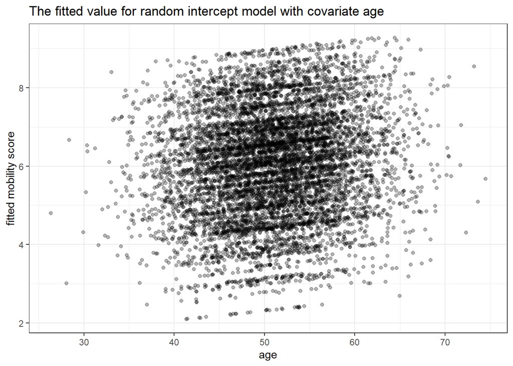

```r
ggplot(fitted_ri, aes(Age, .fitted, group = DID )) +
  geom_point(alpha = 0.3) +
  ylab('fitted mobility score') +
  xlab('age') +
  ggtitle('The fitted value for random intercept model with covariate age') +
  theme_bw()
```

The fitted value for random intercept model with covariate gender

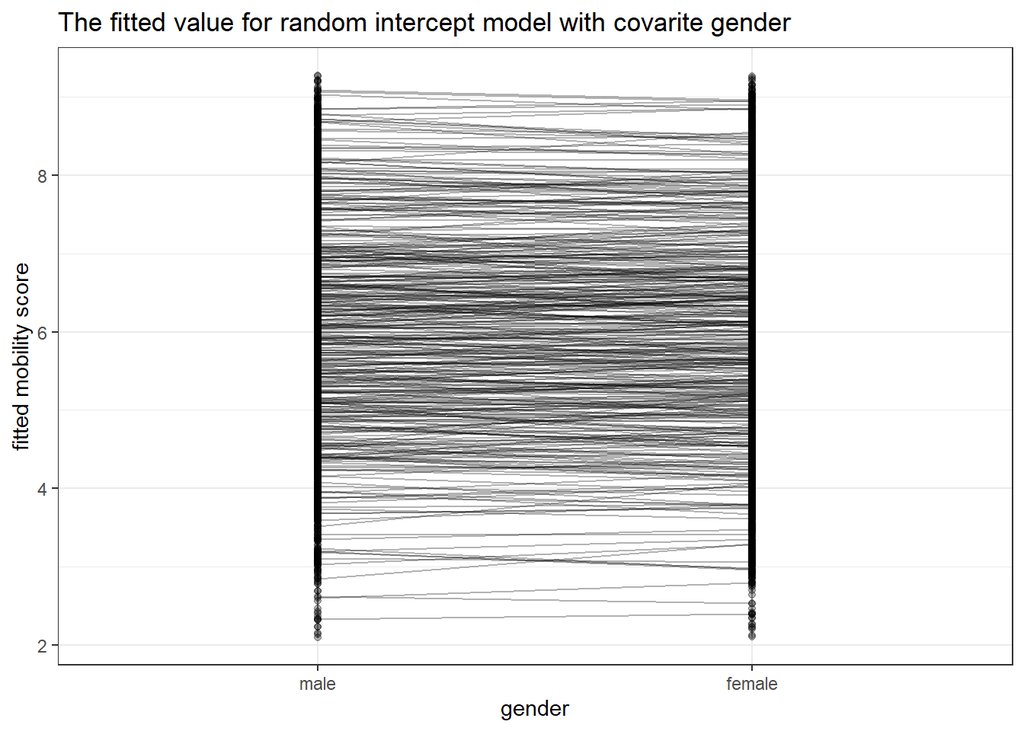

```r
ggplot(fitted_ri, aes(Sex, .fitted, group = DID )) +
  geom_point(alpha = 0.3) +
  geom_line(alpha = 0.3) +
  ylab('fitted mobility score') +
  xlab('gender') +
  ggtitle('The fitted value for random intercept model with covarite gender') +
  theme_bw()
```

The fitted value for random intercept model with covariate Length of Stay

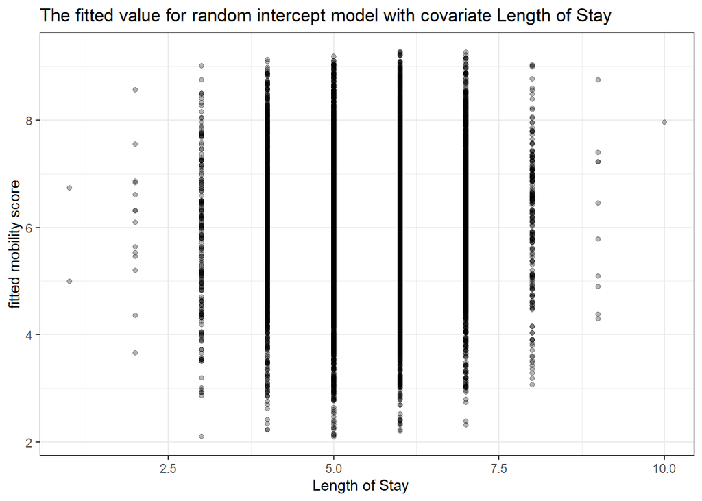

```r
ggplot(fitted_ri, aes(LengthofStay, .fitted, group = DID )) +
  geom_point(alpha = 0.3) +
  ylab('fitted mobility score') +
  xlab('Length of Stay   ') +
  ggtitle('The fitted value for random intercept model with covariate Length of Stay') +
  theme_bw()
```

The fitted value for random intercept model with covariate Experiences

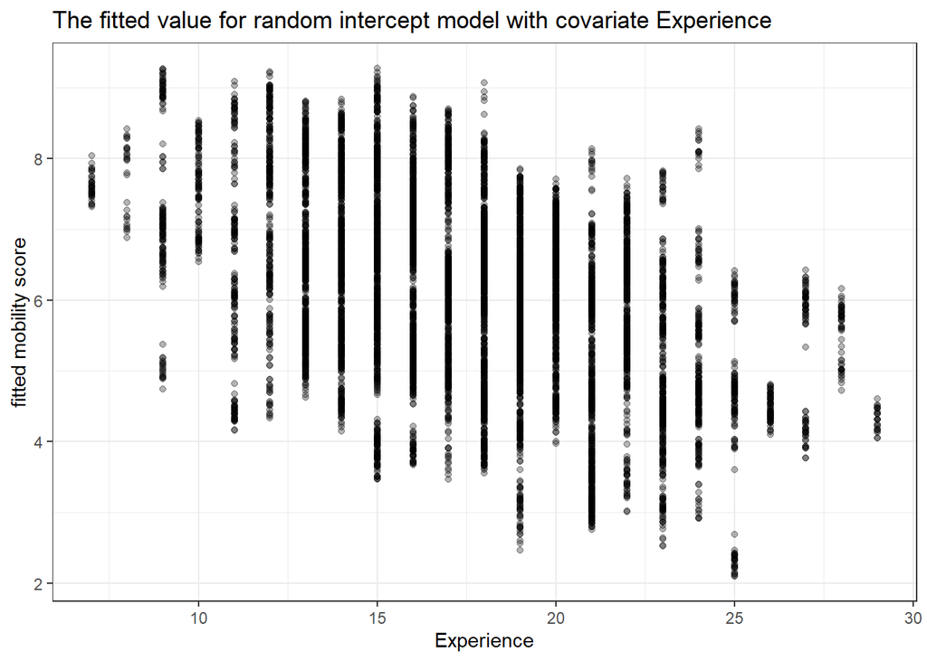

```r
ggplot(fitted_ri, aes(Experience, .fitted, group = DID )) +
  geom_point(alpha = 0.3) +
  ylab('fitted mobility score') +
  xlab('Experience') +
  ggtitle('The fitted value for random intercept model with covariate Experience') +
  theme_bw()
```

## **Random slope models**

This will allow different slopes.

In our example, for random intercept model, we allowed for treating doctor effect on the mean score by allowing the intercept of the regression of mobility score on covariates to vary randomly across treating doctors. We assumed, however, that changes in covariates in mobility score are the same for all treating doctors, i.e. the slope of the regression line was assumed fixed across all treating doctors.

We will now extend the random intercept model fitted before to allow both the intercept and the slope to vary randomly across all treating doctors. Does the Working Experience (random slope) has variation across different DID (treating physician)?

```r
rs <- lmer(mobility ~ Age + Sex + LengthofStay +  Experience + (1 + Experience | DID),
           data = cancer_1, REML = FALSE)
# Summary of the model
summary(rs)
```

```
Linear mixed model fit by maximum likelihood . t-tests use Satterthwaite's
  method [lmerModLmerTest]
Formula: mobility ~ Age + Sex + LengthofStay + Experience + (1 + Experience |
    DID)
   Data: cancer_1

     AIC      BIC   logLik deviance df.resid
 16666.0  16729.4  -8324.0  16648.0     8516

Scaled residuals:
    Min      1Q  Median      3Q     Max
-3.9910 -0.6729 -0.0009  0.6554  3.6368

Random effects:
 Groups   Name        Variance  Std.Dev. Corr
 DID      (Intercept) 1.405e+00 1.185427
          Experience  7.738e-06 0.002782 -0.10
 Residual             3.361e-01 0.579782
Number of obs: 8525, groups:  DID, 407

Fixed effects:
               Estimate Std. Error         df t value Pr(>|t|)
(Intercept)   7.534e+00  2.727e-01  3.756e+02  27.624   <2e-16 ***
Age           2.547e-02  1.149e-03  8.132e+03  22.172   <2e-16 ***
Sexfemale    -1.247e-02  1.315e-02  8.133e+03  -0.949    0.343
LengthofStay -7.945e-03  6.854e-03  8.133e+03  -1.159    0.246
Experience   -1.552e-01  1.477e-02  4.013e+02 -10.511   <2e-16 ***
---
Signif. codes:  0 '***' 0.001 '**' 0.01 '*' 0.05 '.' 0.1 ' ' 1

Correlation of Fixed Effects:
            (Intr) Age    Sexfml LngthS
Age         -0.151
Sexfemale   -0.029  0.000
LengthofSty -0.040 -0.452  0.001
Experience  -0.956 -0.001  0.000 -0.001
optimizer (nloptwrap) convergence code: 0 (OK)
Model failed to converge with max|grad| = 0.0543697 (tol = 0.002, component 1)
```

However, our model failed to converge, so we may switch to `bobyqa` optimizer

```r
rs <- lmer(mobility ~ Age + Sex + LengthofStay +  Experience + (1 + Experience | DID),  data = cancer_1, control = lmerControl(optimizer = 'bobyqa'),
           REML = FALSE)
```

```
boundary (singular) fit: see help('isSingular')
```

```r
summary (rs)
```

```
Linear mixed model fit by maximum likelihood . t-tests use Satterthwaite's
  method [lmerModLmerTest]
Formula: mobility ~ Age + Sex + LengthofStay + Experience + (1 + Experience |
    DID)
   Data: cancer_1
Control: lmerControl(optimizer = "bobyqa")

     AIC      BIC   logLik deviance df.resid
 16666.0  16729.4  -8324.0  16648.0     8516

Scaled residuals:
    Min      1Q  Median      3Q     Max
-3.9910 -0.6729 -0.0009  0.6554  3.6368

Random effects:
 Groups   Name        Variance  Std.Dev.  Corr
 DID      (Intercept) 1.406e+00 1.1858558
          Experience  5.494e-08 0.0002344 -1.00
 Residual             3.361e-01 0.5797810
Number of obs: 8525, groups:  DID, 407

Fixed effects:
               Estimate Std. Error         df t value Pr(>|t|)
(Intercept)   7.534e+00  2.727e-01  3.791e+02  27.622   <2e-16 ***
Age           2.547e-02  1.149e-03  8.132e+03  22.172   <2e-16 ***
Sexfemale    -1.247e-02  1.315e-02  8.133e+03  -0.949    0.343
LengthofStay -7.945e-03  6.854e-03  8.133e+03  -1.159    0.246
Experience   -1.552e-01  1.477e-02  4.062e+02 -10.512   <2e-16 ***
---
Signif. codes:  0 '***' 0.001 '**' 0.01 '*' 0.05 '.' 0.1 ' ' 1

Correlation of Fixed Effects:
            (Intr) Age    Sexfml LngthS
Age         -0.151
Sexfemale   -0.029  0.000
LengthofSty -0.040 -0.452  0.001
Experience  -0.956 -0.001  0.000 -0.001
optimizer (bobyqa) convergence code: 0 (OK)
boundary (singular) fit: see help('isSingular')
```

#### Tabulation of result

```r
tidy(rs, conf.int = TRUE ) %>% kbl() %>%
  kable_styling()
```

| effect | group | term | estimate | std.error | statistic | df | p.value | conf.low | conf.high |
| --- | --- | --- | --- | --- | --- | --- | --- | --- | --- |
| fixed | NA | (Intercept) | 7.5337926 | 0.2727437 | 27.6222446 | 379.1433 | 0.0000000 | 6.9975129 | 8.0700723 |
| fixed | NA | Age | 0.0254661 | 0.0011486 | 22.1723779 | 8132.3025 | 0.0000000 | 0.0232147 | 0.0277176 |
| fixed | NA | Sexfemale | -0.0124710 | 0.0131468 | -0.9486027 | 8132.9317 | 0.3428509 | -0.0382421 | 0.0133000 |
| fixed | NA | LengthofStay | -0.0079450 | 0.0068542 | -1.1591486 | 8132.5941 | 0.2464296 | -0.0213809 | 0.0054909 |
| fixed | NA | Experience | -0.1552161 | 0.0147660 | -10.5116997 | 406.2096 | 0.0000000 | -0.1842434 | -0.1261887 |
| ran_pars | DID | sd__(Intercept) | 1.1858558 | NA | NA | NA | NA | NA | NA |
| ran_pars | DID | cor__(Intercept).Experience | -1.0000000 | NA | NA | NA | NA | NA | NA |
| ran_pars | DID | sd__Experience | 0.0002344 | NA | NA | NA | NA | NA | NA |
| ran_pars | Residual | sd__Observation | 0.5797810 | NA | NA | NA | NA | NA | NA |

#### Interpretation

  **Interpret the random slope and intercept together (random effect)**
- The working experience effect for DID is estimated as -0.1552161+ random_slope_experience. Between DID variance in these slopes estimated as 5.494e-08 (Variance of experience in random effect).
- For average DID, we predict decrease in the mobility score by approximately -0.1552161for each additional years of experience. 95% coverage interval for the DID slopes is estimated as - 0.1552161+/- 1.96 (Sqrt(5.494e-08)) which were between -0.154 and -0.156. Thus, assuming a normal distribution, we would expect the middle 95% of DID to have a slope between -0.154 and -0.156.

  ```r
  -0.1552161 + (1.96 * sqrt(5.494e-08))
  ```

  ```
  [1] -0.1547567
  ```

  ```r
  -0.1552161 - (1.96 * sqrt(5.494e-08))
  ```

  ```
  [1] -0.1556755
  ```

- The correlation between the random intercept and the Experience effect is -1, indicating a perfect negative correlation. This means that as the intercept increases, the Experience effect (slope) decreases proportionally, and vice versa.
- The standard deviation of the random slope for Experience across different groups is very close to zero (0.0002344), suggesting that there is almost no variability in the effect of Experience across the treating doctors.

#### **Prediction**

extract random effect

```r
head(ranef(rs), 3)
```

```
$DID
     (Intercept)    Experience
1   -2.578890007  5.097398e-04
2   -1.311252224  2.591803e-04
3   -1.911369827  3.777987e-04
4   -2.044054353  4.040249e-04
5   -1.709130374  3.378243e-04
6   -0.219327072  4.335188e-05
7   -0.992529964  1.961821e-04
8   -2.425350307  4.793913e-04
9    0.192283877 -3.800656e-05
10  -0.868864982  1.717386e-04
11   1.086744767 -2.148044e-04
12   0.241876762 -4.780902e-05
13   1.073437299 -2.121741e-04
```

[output cut: 394 more lines]

extract fixed effect

```r
fixef(rs)
```

```
 (Intercept)          Age    Sexfemale LengthofStay   Experience
 7.533792584  0.025466105 -0.012471050 -0.007945003 -0.155216072
```

Manual Calculation predicted value for 5th Observation

```r
cancer_1[5,]
```

```
  mobility      Age  Sex LengthofStay Experience HID DID
5        2 46.80042 male            6         25   1   1
```

**Equation : FixIntercept + random intercept for DID 1 + b1age + b2sex + b3lengthofstay + b4experience + Random_Slope for experience for DID 1**

```r
pre_5th_rs <- (7.533792584) +   (- 2.578890007) + (0.025466105*46.80042) + (-0.012471050 *0) + (-0.007945003*6) + (-0.155216072 *25) + (5.097398e-04    * 25)
pre_5th_rs
```

```
[1] 2.231399
```

Recheck the 5th observation

```r
fitted_ri_rs <- augment (rs)
fitted_ri_rs
```

```
# A tibble: 8,525 × 17
   mobility   Age Sex    LengthofStay Experience   DID .fitted .resid   .hat
      <dbl> <dbl> <fct>         <dbl>      <dbl> <dbl>   <dbl>  <dbl>  <dbl>
 1        2  65.0 male              6         25     1    2.69 -0.694 0.0363
 2        2  53.9 female            6         25     1    2.40 -0.400 0.0356
 3        2  53.3 female            5         25     1    2.39 -0.394 0.0356
 4        2  41.4 male              5         25     1    2.10 -0.101 0.0358
 5        2  46.8 male              6         25     1    2.23 -0.231 0.0357
 6        2  51.9 male              5         25     1    2.37 -0.370 0.0356
 7        2  53.8 female            4         25     1    2.41 -0.414 0.0359
 8        3  46.6 male              5         25     1    2.23  0.767 0.0356
 9        3  54.4 male              6         25     1    2.42  0.575 0.0356
10        3  50.5 male              7         25     1    2.32  0.681 0.0359
# ℹ 8,515 more rows
# ℹ 8 more variables: .cooksd <dbl>, .fixed <dbl>, .mu <dbl>, .offset <dbl>,
#   .sqrtXwt <dbl>, .sqrtrwt <dbl>, .weights <dbl>, .wtres <dbl>
```

#### Plot

```r
ra.eff.rs <- ranef(rs, condVar = TRUE)
ra.eff.rs
```

```
$DID
     (Intercept)    Experience
1   -2.578890007  5.097398e-04
2   -1.311252224  2.591803e-04
3   -1.911369827  3.777987e-04
4   -2.044054353  4.040249e-04
5   -1.709130374  3.378243e-04
6   -0.219327072  4.335188e-05
7   -0.992529964  1.961821e-04
8   -2.425350307  4.793913e-04
9    0.192283877 -3.800656e-05
10  -0.868864982  1.717386e-04
11   1.086744767 -2.148044e-04
12   0.241876762 -4.780902e-05
13   1.073437299 -2.121741e-04
```

[output cut: 396 more lines]

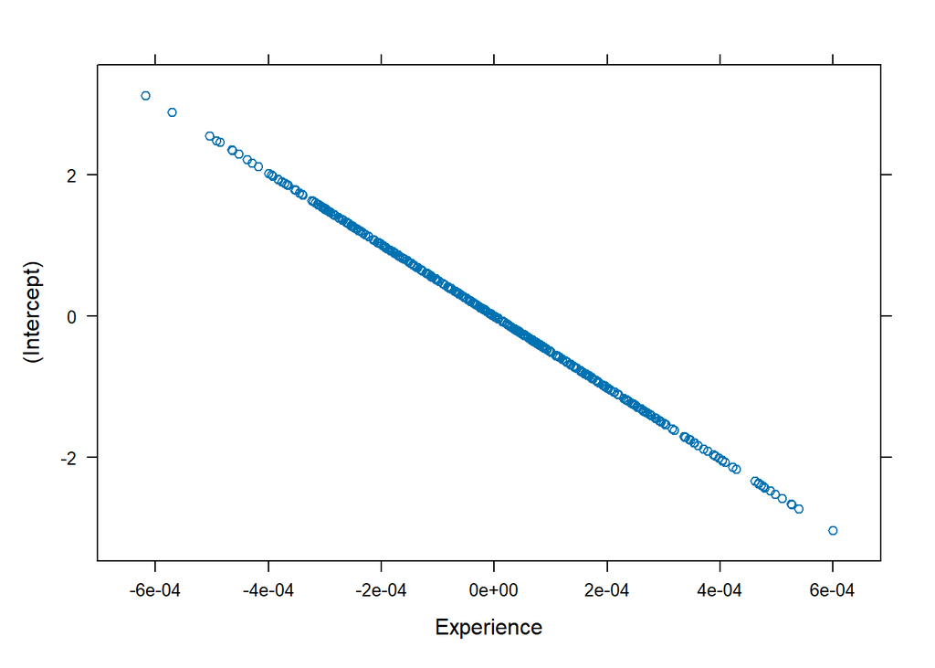

```r
plot(ra.eff.rs)
```

## Model Comparison

Lets compare between 2 models.

```r
anova( ri, rs)
```

```
Data: cancer_1
Models:
ri: mobility ~ Age + Sex + LengthofStay + Experience + (1 | DID)
rs: mobility ~ Age + Sex + LengthofStay + Experience + (1 + Experience | DID)
   npar   AIC   BIC logLik deviance Chisq Df Pr(>Chisq)
ri    7 16662 16711  -8324    16648
rs    9 16666 16729  -8324    16648 5e-04  2     0.9998
```

The AIC of model with random slope is almost similar to the model with random intercept. There are no significant improvement in model fit by adding random slope in model **rs**. Given the p-value 0.9998, we failed to reject the null hypothesis therefore simpler model (**ri**) is preferred. We conclude that, working experience effect had no random effect to treating doctor (DID).

## **Data Presentation**

```r
tbl_regression(ri)
```

| **Characteristic** | **Beta** | **95% CI**<sup>1</sup> | **p-value** |
| --- | --- | --- | --- |
| Age | 0.03 | 0.02, 0.03 | <0.001 |
| Sex |  |  |  |
| male | — | — |  |
| female | -0.01 | -0.04, 0.01 | 0.3 |
| LengthofStay | -0.01 | -0.02, 0.01 | 0.2 |
| Experience | -0.16 | -0.18, -0.13 | <0.001 |

<sup>1</sup> CI = Confidence Interval

or using sjPlot packages

```r
tab_model(ri)
```

|  | mobility |  |  |
| --- | --- | --- | --- |
| Predictors | Estimates | CI | p |
| (Intercept) | 7.53 | 7.00 – 8.07 | **<0.001** |
| Age | 0.03 | 0.02 – 0.03 | **<0.001** |
| Sex [female] | -0.01 | -0.04 – 0.01 | 0.343 |
| LengthofStay | -0.01 | -0.02 – 0.01 | 0.246 |
| Experience | -0.16 | -0.18 – -0.13 | **<0.001** |
| Random Effects |  |  |  |
| σ<sup>2</sup> | 0.34 |  |  |
| τ<sub>00</sub> <sub>DID</sub> | 1.40 |  |  |
| ICC | 0.81 |  |  |
| N <sub>DID</sub> | 407 |  |  |
| Observations | 8525 |  |  |
| Marginal R<sup>2</sup> / Conditional R<sup>2</sup> | 0.195 / 0.844 |  |  |

Plot random effect

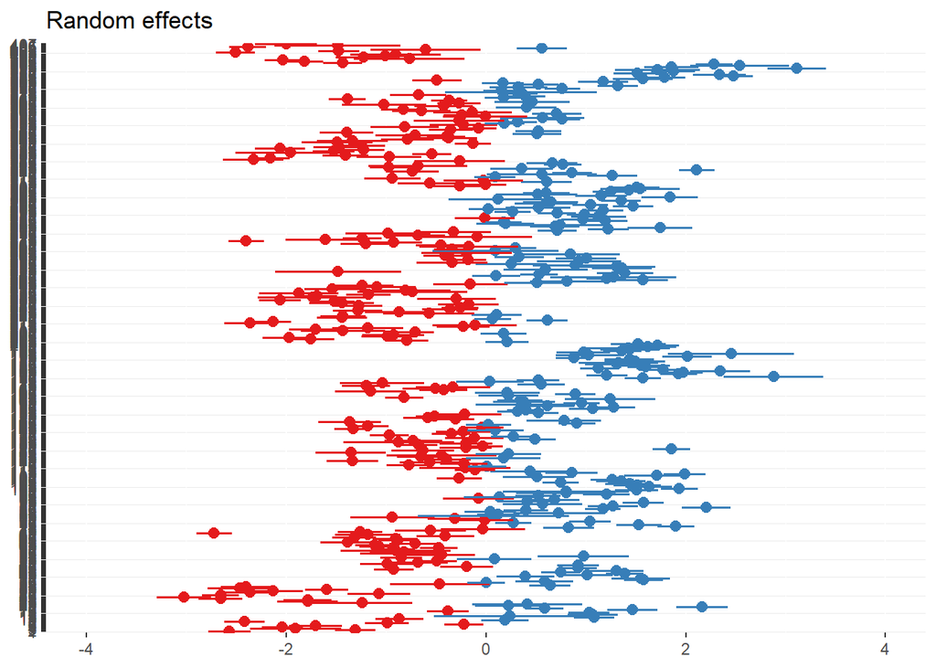

```r
plot_model(ri, type = 're')
```

Plot shows the variability in the random intercepts for each treating doctor (DID) in the **ri** model. It indicates how much each DID’s intercept differs from the overall mean intercept. The random effects vary significantly across treating doctors (DID), as shown by the spread of the points along the X-axis. This variability suggests that there are meaningful differences between the DID in determining the mobility score after accounting for Age, Sex, Length of Stay, and Experience.